# Laboratorium 17

Do wykresu z poprzedniego laboratorium dodano węzły:

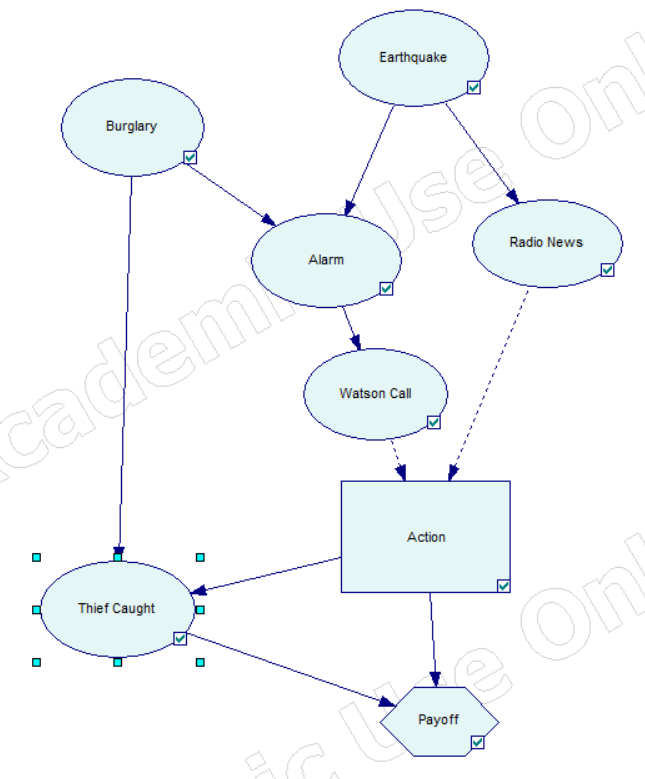

- **Thief Caught** - szanse na złapanie złodzieja.

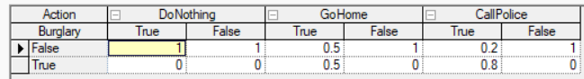

- **Action** - blok decyzyjny o podejmowanej przez Holmesa kroku.

*Nic nie rób*, *Jedź do domu*, *Dzwoń na policję*.

- **Payoff** - blok użyteczności, przedstawiający zysk lub stratę w kontekście podjętych kroków, ustawione w skali -100 do 2000.

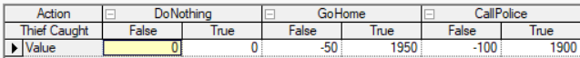

### Wartości payoff dla każdej akcji:

**Do nothing**:

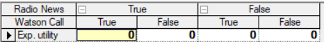

**Go home**:

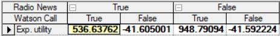

**Call police**:

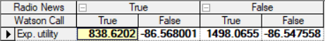

### Przykład działania:

1. Holmes otrzymuje telefon od Watsona, nic nie słyszy w radiu o trzęsieniu. Podejmuje decyzję o tym, że sam pojedzie do domu. Niestety nie łapie złodzieja w pojedynkę:

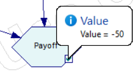

Nie był to najlepszy pomysł, stracił jedynie czas.

3. Nie wiadomo, czy nastąpiło włamanie. Telefon od Watsona zadzwonił, a w radiu nic nie było o trzęsieniu ziemi. Holmes więc ponownie dzwoni na policję.

Dodatkowo, okazuje się, że policja złapała złodzieja:

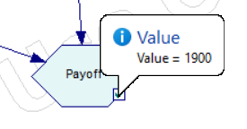

Holmes podjął dobrą decyzję, wynik payoff jest bardzo wysoki.